# Demo #3 - ABM project

2020-03-24

## Background

**Goal:**

> Replace the previous ABM ie Annual Bibliometric Monitoring / Årlig Bibliometrisk Uppföljning at KTH

Our [previous demo meeting](https://KTH-Library.github.io/demo-2) was held 2019-12-05.

Since then (> **3 months ago**) we have worked on Sprints **8 to 11** (current)

## Agenda

The [1.0 release is done](https://kth.se/abm), three releases have been published so far

- Progress - What is **new** since last meeting?
- A short **demo** of the ABM app
- Future **directions** after 1.0 release
- Our **questions** to you
- Your **feedback** and your suggestions and comments to us

## ABM 1.0

The first step of the project plan was a re-implementation of the old ABM.

- More attractive and dynamic **presentation**
- Same results, based on **DiVA and Bibmet**
- New : Share of **uncited** publications
- New : Overview for **Open Access** publications
- New : Notes to help with **interpretation** of indicators/results

There is now a public version of the app showing breakdowns for KTH units. It allows researchers to login using their KTH account to view their own data.

## Live demo - ABM dashboard

Demo of Dashboard / Shiny App

[interactive chart not shown]

## Open Access data in ABM

- Open Access status and category as determined by **Unpaywall**
  - Status: OA/Not OA. Categories: Gold, Hybrid, Green, Bronze
- Subset of peer-reviewed publications.  
  Criteria: 1) Have a DOI number 2) Be identified by Unpaywall
- Two graphs for category distribution: overview, evolution in time

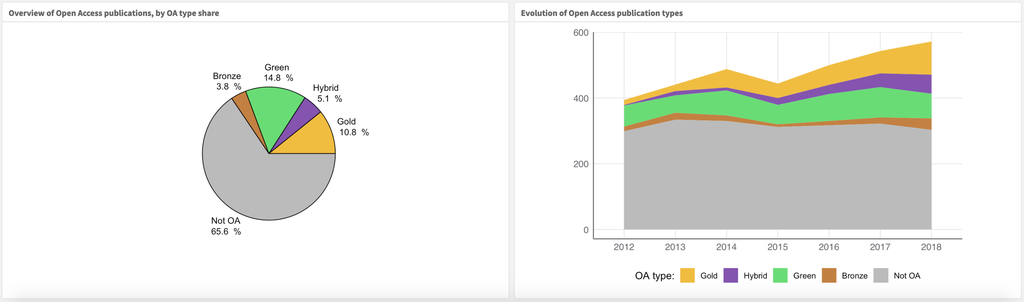

## Uncited publications

- In addition to the total and average number of citations, the number and share of uncited publications are included
- Uncited here means not cited after 3 years (the publication year and the two following years)
- The other end of “Top 10% cited”

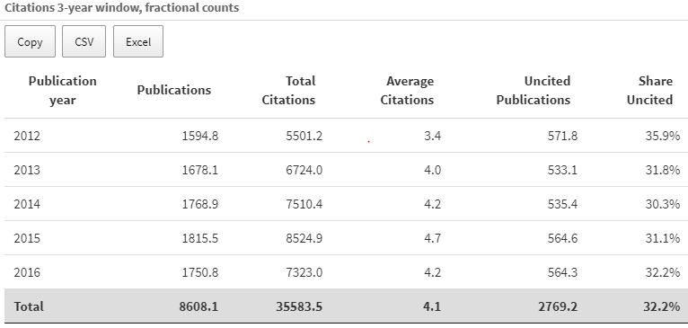

## “Notes”: Coverage and sample size

- The number of publications for the row with least number of publication in each table.
- A warning text if any row is based on less than 50 publications.
- Shows the Web of Science coverage for the row with least coverage in each table.
- Displays **poor**, **moderate** or **good** WoS coverage.
- For individuals, there is a general word of caution for everybody regardless of size or coverage.

## What is planned next for ABM?

## Next phase for ABM

Going forward, we have planned to work on these areas:

- About tab
- More comprehensive co-publication information
- Collaboration networks
- Additional data sources
- Other apps to complement the ABM

Please think about what would be **most interesting to you** in the short run?

## “About” tab

Currently:

- brief information in the **Overview** tab
- longer texts in [**Guide to ABM**](https://kth-library.github.io/abm/ABM_guide.pdf) and other documents linked from **Overview**
- technical documentation at https://KTH-Library.github.io

More information needed, such as:

- Where do these data come from and when was it retrieved?
- What criteria were used to select which publications to include?
- More comprehensive description of indicators
- Outside of the ABM, how is bibliometrics used at KTH?

## Beyond the ABM 1.0 app - Capacity building

## Recap of activities

[figure not shown]

- Items on **checklist** for production release are checked
- Production **roll-out** with a couple of releases ([changelog](https://kth-library.github.io/bibliomatrix/news/index.html))
- Learning together in **workshops**
- [Other (non-ABM-app) **tools**](https://github.com/KTH-Library) are in the pipeline

## Workshops/learning

Feel free to look at these resources if you are interested in the our workflows and potential applications (beyond the ABM 1.0 app) in the future.

- [Agile workflow workshop](https://KTH-Library.github.io/workflow)
- [Operations/maintenance workshop](https://KTH-Library.github.io/operations)
- [Performance improvements workshop](https://KTH-Library.github.io/performance)
- [Web APIs usage workshop](https://KTH-Library.github.io/webapis)
- [Open Data Science Platforms - Trends from FOSDEM20 in Bruxelles](https://KTH-Library.github.io/open-datascience-platforms)

## Other tools being developed

- Access through API wrappers to new data sources
  - Use case described by Chip related to DiVA data quality improvements -> new R packages with API Wrapper clients
    - [`kthapi`](https://github.com/KTH-Library/kthapi) for accessing data from KTH APIs
    - [`dblp`](https://github.com/KTH-Library/dblp) for accessing data from API at https://dblp.org (CS biliographics)
    - [`XsearchLIBRIS`](https://github.com/KTH-Library/XsearchLIBRIS) for searches against LIBRIS and SwePub
  - Co-publication
- KTH Styling for R users: [`ktheme`](https://github.com/KTH-Library/ktheme) … used for example to make these slides

## Questions and feedback

## Questions related to ABM 1.0

- Does the in-dashboard notes to assist in **interpreting indicators** in the case of low `n` help?
- Do you think the [**PDF Guide**](https://kth-library.github.io/abm/ABM_guide.pdf) works? Is it useful?
- What information would you like to see in an **About tab**?
- What do you think is **missing** in the ABM dashboard?
- Should the personal pages also include non-KTH publications?
- Should app data be static (yearly) or continuously updated?

## Thanks for your attention!

## If time permits…

## Technical solution in ÅBU

Open source-based platform for reproducible research including web-friendly data analysis:

- Front-end for open data science [KONTARION](https://github.com/kth-library/kontarion)
- Can do **ML och AI**, scales locally or in the cloud using Docker Swarm / Kubernetes, container-based, supports ML/AI workflows using R, Python (Jupyter) etc… GPU-scaling and [slurm jobs](https://docs.rstudio.com/rsp/integration/launcher-slurm/))
- Add-on: Backend for big data using [Apache Spark + Minio + Select S3](https://docs.google.com/presentation/d/1eGahU6aR9GynYYyka2X-tTLSqLISEGvz7ZzfgfYq6Qw/edit#slide=id.g54b55e0426_0_0)

## Hybrid cloud big/fast data backend

Data Lake w/ Minio + Apache Spark + S3 Select + RStudio Web Edition / JupyterHub

[figure not shown]

[Minio blog article about S3 Select](https://blog.minio.io/running-peta-scale-spark-jobs-on-object-storage-using-s3-select-df7177ae518)

## Stats @ Git Hub …

- GitHub: 42 closed pull request, > 400 commits, 7 repos, 10 open issues and 50 closed
- DockerHub shows 10K+ downloads for [KONTARION](https://hub.docker.com/r/kthb/kontarion)

## Handbook

[figure not shown]

https://therinspark.com/